# Loan Data Exploration

## Preliminary Wrangling

This document explores a dataset containing information on Loan applications.

- Load Libraries
- Assessment Findings
- Clean Data
- Data Storage
- Exploratory Data Analysis
  - Univariate Exploration
  - Bivariate Exploration
  - Multivariate Exploration
- Conclusion

## Load Libraries

```python
import numpy as np
import pandas as pd
import matplotlib.pyplot as plt
import seaborn as sb
%matplotlib inline
```

```python
loan_data = pd.read_csv('data/prosperLoanData.csv')
loan_data.head(5)
```

|  | ListingKey | ListingNumber | ListingCreationDate | CreditGrade | Term | LoanStatus | ClosedDate | BorrowerAPR | BorrowerRate | LenderYield | ... | LP_ServiceFees | LP_CollectionFees | LP_GrossPrincipalLoss | LP_NetPrincipalLoss | LP_NonPrincipalRecoverypayments | PercentFunded | Recommendations | InvestmentFromFriendsCount | InvestmentFromFriendsAmount | Investors |
| --- | --- | --- | --- | --- | --- | --- | --- | --- | --- | --- | --- | --- | --- | --- | --- | --- | --- | --- | --- | --- | --- |
| 0 | 1021339766868145413AB3B | 193129 | 09:29.3 | C | 36 | Completed | 8/14/2009 0:00 | 0.16516 | 0.1580 | 0.1380 | ... | -133.18 | 0.0 | 0.0 | 0.0 | 0.0 | 1.0 | 0 | 0 | 0.0 | 258 |
| 1 | 10273602499503308B223C1 | 1209647 | 28:07.9 | NaN | 36 | Current | NaN | 0.12016 | 0.0920 | 0.0820 | ... | 0.00 | 0.0 | 0.0 | 0.0 | 0.0 | 1.0 | 0 | 0 | 0.0 | 1 |
| 2 | 0EE9337825851032864889A | 81716 | 00:47.1 | HR | 36 | Completed | 12/17/2009 0:00 | 0.28269 | 0.2750 | 0.2400 | ... | -24.20 | 0.0 | 0.0 | 0.0 | 0.0 | 1.0 | 0 | 0 | 0.0 | 41 |
| 3 | 0EF5356002482715299901A | 658116 | 02:35.0 | NaN | 36 | Current | NaN | 0.12528 | 0.0974 | 0.0874 | ... | -108.01 | 0.0 | 0.0 | 0.0 | 0.0 | 1.0 | 0 | 0 | 0.0 | 158 |
| 4 | 0F023589499656230C5E3E2 | 909464 | 38:39.1 | NaN | 36 | Current | NaN | 0.24614 | 0.2085 | 0.1985 | ... | -60.27 | 0.0 | 0.0 | 0.0 | 0.0 | 1.0 | 0 | 0 | 0.0 | 20 |

5 rows × 81 columns

```python
loan_data.shape
```

```
(113937, 81)
```

```python
loan_data.info()
```

```
<class 'pandas.core.frame.DataFrame'>
RangeIndex: 113937 entries, 0 to 113936
Data columns (total 81 columns):
 #   Column                               Non-Null Count   Dtype
---  ------                               --------------   -----
 0   ListingKey                           113937 non-null  object
 1   ListingNumber                        113937 non-null  int64
 2   ListingCreationDate                  113937 non-null  object
 3   CreditGrade                          28953 non-null   object
 4   Term                                 113937 non-null  int64
 5   LoanStatus                           113937 non-null  object
 6   ClosedDate                           55089 non-null   object
 7   BorrowerAPR                          113912 non-null  float64
 8   BorrowerRate                         113937 non-null  float64
 9   LenderYield                          113937 non-null  float64
```

[output cut: 73 more lines]

```python
loan_data.describe()
```

|  | ListingNumber | Term | BorrowerAPR | BorrowerRate | LenderYield | EstimatedEffectiveYield | EstimatedLoss | EstimatedReturn | ProsperRating (numeric) | ProsperScore | ... | LP_ServiceFees | LP_CollectionFees | LP_GrossPrincipalLoss | LP_NetPrincipalLoss | LP_NonPrincipalRecoverypayments | PercentFunded | Recommendations | InvestmentFromFriendsCount | InvestmentFromFriendsAmount | Investors |
| --- | --- | --- | --- | --- | --- | --- | --- | --- | --- | --- | --- | --- | --- | --- | --- | --- | --- | --- | --- | --- | --- |
| count | 1.139370e+05 | 113937.000000 | 113912.000000 | 113937.000000 | 113937.000000 | 84853.000000 | 84853.000000 | 84853.000000 | 84853.000000 | 84853.000000 | ... | 113937.000000 | 113937.000000 | 113937.000000 | 113937.000000 | 113937.000000 | 113937.000000 | 113937.000000 | 113937.000000 | 113937.000000 | 113937.000000 |
| mean | 6.278857e+05 | 40.830248 | 0.218828 | 0.192764 | 0.182701 | 0.168661 | 0.080306 | 0.096068 | 4.072243 | 5.950067 | ... | -54.725641 | -14.242698 | 700.446342 | 681.420499 | 25.142686 | 0.998584 | 0.048027 | 0.023460 | 16.550751 | 80.475228 |
| std | 3.280762e+05 | 10.436212 | 0.080364 | 0.074818 | 0.074516 | 0.068467 | 0.046764 | 0.030403 | 1.673227 | 2.376501 | ... | 60.675425 | 109.232758 | 2388.513831 | 2357.167068 | 275.657937 | 0.017919 | 0.332353 | 0.232412 | 294.545422 | 103.239020 |
| min | 4.000000e+00 | 12.000000 | 0.006530 | 0.000000 | -0.010000 | -0.182700 | 0.004900 | -0.182700 | 1.000000 | 1.000000 | ... | -664.870000 | -9274.750000 | -94.200000 | -954.550000 | 0.000000 | 0.700000 | 0.000000 | 0.000000 | 0.000000 | 1.000000 |
| 25% | 4.009190e+05 | 36.000000 | 0.156290 | 0.134000 | 0.124200 | 0.115670 | 0.042400 | 0.074080 | 3.000000 | 4.000000 | ... | -73.180000 | 0.000000 | 0.000000 | 0.000000 | 0.000000 | 1.000000 | 0.000000 | 0.000000 | 0.000000 | 2.000000 |
| 50% | 6.005540e+05 | 36.000000 | 0.209760 | 0.184000 | 0.173000 | 0.161500 | 0.072400 | 0.091700 | 4.000000 | 6.000000 | ... | -34.440000 | 0.000000 | 0.000000 | 0.000000 | 0.000000 | 1.000000 | 0.000000 | 0.000000 | 0.000000 | 44.000000 |
| 75% | 8.926340e+05 | 36.000000 | 0.283810 | 0.250000 | 0.240000 | 0.224300 | 0.112000 | 0.116600 | 5.000000 | 8.000000 | ... | -13.920000 | 0.000000 | 0.000000 | 0.000000 | 0.000000 | 1.000000 | 0.000000 | 0.000000 | 0.000000 | 115.000000 |
| max | 1.255725e+06 | 60.000000 | 0.512290 | 0.497500 | 0.492500 | 0.319900 | 0.366000 | 0.283700 | 7.000000 | 11.000000 | ... | 32.060000 | 0.000000 | 25000.000000 | 25000.000000 | 21117.900000 | 1.012500 | 39.000000 | 33.000000 | 25000.000000 | 1189.000000 |

8 rows × 61 columns

```python
loan_data[loan_data.ListingNumber.duplicated()]
```

|  | ListingKey | ListingNumber | ListingCreationDate | CreditGrade | Term | LoanStatus | ClosedDate | BorrowerAPR | BorrowerRate | LenderYield | ... | LP_ServiceFees | LP_CollectionFees | LP_GrossPrincipalLoss | LP_NetPrincipalLoss | LP_NonPrincipalRecoverypayments | PercentFunded | Recommendations | InvestmentFromFriendsCount | InvestmentFromFriendsAmount | Investors |
| --- | --- | --- | --- | --- | --- | --- | --- | --- | --- | --- | --- | --- | --- | --- | --- | --- | --- | --- | --- | --- | --- |
| 9 | 0F043596202561788EA13D5 | 1023355 | 43:39.1 | NaN | 36 | Current | NaN | 0.07620 | 0.0629 | 0.0529 | ... | -16.77 | 0.0 | 0.0 | 0.0 | 0.0 | 1.0 | 0 | 0 | 0.0 | 1 |
| 999 | 0A0635972629771021E38F3 | 1055932 | 25:17.1 | NaN | 60 | Current | NaN | 0.17710 | 0.1535 | 0.1435 | ... | 0.00 | 0.0 | 0.0 | 0.0 | 0.0 | 1.0 | 0 | 0 | 0.0 | 1 |
| 2539 | 2D2635984503681189056B4 | 1097584 | 50:08.0 | NaN | 60 | Current | NaN | 0.14528 | 0.1224 | 0.1124 | ... | 0.00 | 0.0 | 0.0 | 0.0 | 0.0 | 1.0 | 0 | 0 | 0.0 | 1 |
| 4942 | 4B7E3590031274113F1FD34 | 927246 | 35:36.3 | NaN | 36 | Current | NaN | 0.35356 | 0.3134 | 0.3034 | ... | -15.98 | 0.0 | 0.0 | 0.0 | 0.0 | 1.0 | 0 | 0 | 0.0 | 40 |
| 5812 | 94B035909835592957503E6 | 920397 | 27:48.3 | NaN | 36 | Current | NaN | 0.24205 | 0.2045 | 0.1945 | ... | -37.03 | 0.0 | 0.0 | 0.0 | 0.0 | 1.0 | 0 | 0 | 0.0 | 1 |
| ... | ... | ... | ... | ... | ... | ... | ... | ... | ... | ... | ... | ... | ... | ... | ... | ... | ... | ... | ... | ... | ... |
| 113548 | FB6A35999320129979DBBA3 | 1158474 | 33:26.0 | NaN | 60 | Current | NaN | 0.22063 | 0.1960 | 0.1860 | ... | 0.00 | 0.0 | 0.0 | 0.0 | 0.0 | 1.0 | 0 | 0 | 0.0 | 1 |
| 113636 | D9BF3589576999233477E75 | 904020 | 44:43.2 | NaN | 36 | Current | NaN | 0.21290 | 0.1760 | 0.1660 | ... | -9.86 | 0.0 | 0.0 | 0.0 | 0.0 | 1.0 | 0 | 0 | 0.0 | 1 |
| 113733 | E2303594522341016B8EE15 | 1002326 | 26:31.3 | NaN | 60 | Current | NaN | 0.20593 | 0.1819 | 0.1719 | ... | -24.94 | 0.0 | 0.0 | 0.0 | 0.0 | 1.0 | 0 | 0 | 0.0 | 66 |
| 113773 | DE8535960513435199406CE | 1056749 | 43:13.8 | NaN | 36 | Current | NaN | 0.16324 | 0.1274 | 0.1174 | ... | -16.79 | 0.0 | 0.0 | 0.0 | 0.0 | 1.0 | 0 | 0 | 0.0 | 1 |
| 113863 | C74335893905744205D4056 | 928893 | 53:34.6 | NaN | 36 | Current | NaN | 0.12691 | 0.0990 | 0.0890 | ... | -15.99 | 0.0 | 0.0 | 0.0 | 0.0 | 1.0 | 0 | 0 | 0.0 | 1 |

871 rows × 81 columns

Here I noticed ListingNumber and ListingKey appear more than once in some cases, however in the row there are some new information. So the rows themselves are not duplicates.

# Assessment Findings

Back to Top

#### Tidy

##### `loan_data`

- Several columns not needed for analysis; remove unnecessary data
- Change names of columns with spacing and parenthesis

#### Quality

##### `loan_data`

- DataFrame has duplicated data in ListingKey and ListingNumber
- Listing Number is an integer but should be an object
- Listing Creation Date should be date
- Term is an integer but should be an object
- Close date should be a date
- Listing Category (numeric) is an integer and should be an object
- Date Credit Pulled is an object should be a date

# Clean Data

Back to Top

## Define

- Drop unnecessary data

For my analysis, there are several columns that I will not need. For example, ListingKey is irrelevant and just takes up memory and resources. I have previewed the data and determined what I will need for exploration of the data set. If I determine later that I removed information that I needed, I can always reload the original csv file into a new dataframe.

That being said, I will copy the dataframe before dropping columns.

## Code

```python
# First step is to make a copy
loan_CL = loan_data.copy()
loan_CL.drop(['ListingKey','ClosedDate',
       'ListingCategory (numeric)', 'CurrentlyInGroup', 'GroupKey',
       'DateCreditPulled', 'FirstRecordedCreditLine', 'CurrentCreditLines',
       'OpenCreditLines', 'TotalCreditLinespast7years', 'InquiriesLast6Months',
       'TotalInquiries', 'DelinquenciesLast7Years', 'PublicRecordsLast10Years',
       'PublicRecordsLast12Months', 'BankcardUtilization', 'AvailableBankcardCredit',
       'TotalTrades', 'TradesNeverDelinquent (percentage)', 'TradesOpenedLast6Months',
       'IncomeVerifiable', 'LoanKey', 'TotalProsperLoans',
       'TotalProsperPaymentsBilled', 'OnTimeProsperPayments', 'ProsperPaymentsLessThanOneMonthLate',
       'ProsperPaymentsOneMonthPlusLate', 'ProsperPrincipalBorrowed', 'ProsperPrincipalOutstanding',
       'ScorexChangeAtTimeOfListing', 'LoanCurrentDaysDelinquent', 'LoanFirstDefaultedCycleNumber',
       'LoanMonthsSinceOrigination', 'LoanNumber', 'MemberKey',
       'LP_CustomerPayments', 'LP_CustomerPrincipalPayments', 'LP_InterestandFees',
       'LP_ServiceFees', 'LP_CollectionFees', 'LP_GrossPrincipalLoss',
       'LP_NetPrincipalLoss', 'LP_NonPrincipalRecoverypayments', 'PercentFunded',
       'Recommendations','InvestmentFromFriendsCount', 'InvestmentFromFriendsAmount'
], axis=1, inplace=True)
```

## Test

```python
loan_CL.head(2)
```

|  | ListingNumber | ListingCreationDate | CreditGrade | Term | LoanStatus | BorrowerAPR | BorrowerRate | LenderYield | EstimatedEffectiveYield | EstimatedLoss | ... | AmountDelinquent | RevolvingCreditBalance | DebtToIncomeRatio | IncomeRange | StatedMonthlyIncome | LoanOriginalAmount | LoanOriginationDate | LoanOriginationQuarter | MonthlyLoanPayment | Investors |
| --- | --- | --- | --- | --- | --- | --- | --- | --- | --- | --- | --- | --- | --- | --- | --- | --- | --- | --- | --- | --- | --- |
| 0 | 193129 | 09:29.3 | C | 36 | Completed | 0.16516 | 0.158 | 0.138 | NaN | NaN | ... | 472.0 | 0.0 | 0.17 | $25,000-49,999 | 3083.333333 | 9425 | 9/12/2007 0:00 | Q3 2007 | 330.43 | 258 |
| 1 | 1209647 | 28:07.9 | NaN | 36 | Current | 0.12016 | 0.092 | 0.082 | 0.0796 | 0.0249 | ... | 0.0 | 3989.0 | 0.18 | $50,000-74,999 | 6125.000000 | 10000 | 3/3/2014 0:00 | Q1 2014 | 318.93 | 1 |

2 rows × 34 columns

```python
loan_CL.columns
```

```
Index(['ListingNumber', 'ListingCreationDate', 'CreditGrade', 'Term',
       'LoanStatus', 'BorrowerAPR', 'BorrowerRate', 'LenderYield',
       'EstimatedEffectiveYield', 'EstimatedLoss', 'EstimatedReturn',
       'ProsperRating (numeric)', 'ProsperRating (Alpha)', 'ProsperScore',
       'BorrowerState', 'Occupation', 'EmploymentStatus',
       'EmploymentStatusDuration', 'IsBorrowerHomeowner',
       'CreditScoreRangeLower', 'CreditScoreRangeUpper',
       'OpenRevolvingAccounts', 'OpenRevolvingMonthlyPayment',
       'CurrentDelinquencies', 'AmountDelinquent', 'RevolvingCreditBalance',
       'DebtToIncomeRatio', 'IncomeRange', 'StatedMonthlyIncome',
       'LoanOriginalAmount', 'LoanOriginationDate', 'LoanOriginationQuarter',
       'MonthlyLoanPayment', 'Investors'],
      dtype='object')
```

```python
loan_CL.info()
```

```
<class 'pandas.core.frame.DataFrame'>
RangeIndex: 113937 entries, 0 to 113936
Data columns (total 34 columns):
 #   Column                       Non-Null Count   Dtype
---  ------                       --------------   -----
 0   ListingNumber                113937 non-null  int64
 1   ListingCreationDate          113937 non-null  object
 2   CreditGrade                  28953 non-null   object
 3   Term                         113937 non-null  int64
 4   LoanStatus                   113937 non-null  object
 5   BorrowerAPR                  113912 non-null  float64
 6   BorrowerRate                 113937 non-null  float64
 7   LenderYield                  113937 non-null  float64
 8   EstimatedEffectiveYield      84853 non-null   float64
 9   EstimatedLoss                84853 non-null   float64
```

[output cut: 26 more lines]

Reduced dataframe from 68.1 Mb to 28.8 Mb.

## Define

- Drop duplicate data
- ListingNumber may be duplicated but data in row is unique

```python
loan_CL.ListingNumber.is_unique
```

```
False
```

## Code

```python
loan_CL.drop_duplicates(keep=False, inplace=True)
```

## Test

```python
loan_CL.info()
```

```
<class 'pandas.core.frame.DataFrame'>
Int64Index: 113937 entries, 0 to 113936
Data columns (total 34 columns):
 #   Column                       Non-Null Count   Dtype
---  ------                       --------------   -----
 0   ListingNumber                113937 non-null  int64
 1   ListingCreationDate          113937 non-null  object
 2   CreditGrade                  28953 non-null   object
 3   Term                         113937 non-null  int64
 4   LoanStatus                   113937 non-null  object
 5   BorrowerAPR                  113912 non-null  float64
 6   BorrowerRate                 113937 non-null  float64
 7   LenderYield                  113937 non-null  float64
 8   EstimatedEffectiveYield      84853 non-null   float64
 9   EstimatedLoss                84853 non-null   float64
```

[output cut: 26 more lines]

## Define

- Change names of various columns

## Code

```python
loan_CL.rename(columns = {'ProsperRating (Alpha)' : 'ProsperRating_alpha',
                           'ProsperRating (numeric)' : 'ProsperRating_numeric'}, inplace=True)
```

## Test

```python
loan_CL.columns
```

```
Index(['ListingNumber', 'ListingCreationDate', 'CreditGrade', 'Term',
       'LoanStatus', 'BorrowerAPR', 'BorrowerRate', 'LenderYield',
       'EstimatedEffectiveYield', 'EstimatedLoss', 'EstimatedReturn',
       'ProsperRating_numeric', 'ProsperRating_alpha', 'ProsperScore',
       'BorrowerState', 'Occupation', 'EmploymentStatus',
       'EmploymentStatusDuration', 'IsBorrowerHomeowner',
       'CreditScoreRangeLower', 'CreditScoreRangeUpper',
       'OpenRevolvingAccounts', 'OpenRevolvingMonthlyPayment',
       'CurrentDelinquencies', 'AmountDelinquent', 'RevolvingCreditBalance',
       'DebtToIncomeRatio', 'IncomeRange', 'StatedMonthlyIncome',
       'LoanOriginalAmount', 'LoanOriginationDate', 'LoanOriginationQuarter',
       'MonthlyLoanPayment', 'Investors'],
      dtype='object')
```

## Define

- Change datatypes of various columns
- Change dates to datetime values

## Code

```python
loan_CL.ListingNumber = loan_CL.ListingNumber.astype(str)
loan_CL.LoanOriginationDate = pd.to_datetime(loan_CL.LoanOriginationDate)
loan_CL.Term = loan_CL.Term.astype("category")
```

## Test

```python
loan_CL.info()
```

```
<class 'pandas.core.frame.DataFrame'>
Int64Index: 113937 entries, 0 to 113936
Data columns (total 34 columns):
 #   Column                       Non-Null Count   Dtype
---  ------                       --------------   -----
 0   ListingNumber                113937 non-null  object
 1   ListingCreationDate          113937 non-null  object
 2   CreditGrade                  28953 non-null   object
 3   Term                         113937 non-null  category
 4   LoanStatus                   113937 non-null  object
 5   BorrowerAPR                  113912 non-null  float64
 6   BorrowerRate                 113937 non-null  float64
 7   LenderYield                  113937 non-null  float64
 8   EstimatedEffectiveYield      84853 non-null   float64
 9   EstimatedLoss                84853 non-null   float64
```

[output cut: 26 more lines]

```python
loan_CL.head(2)
```

|  | ListingNumber | ListingCreationDate | CreditGrade | Term | LoanStatus | BorrowerAPR | BorrowerRate | LenderYield | EstimatedEffectiveYield | EstimatedLoss | ... | AmountDelinquent | RevolvingCreditBalance | DebtToIncomeRatio | IncomeRange | StatedMonthlyIncome | LoanOriginalAmount | LoanOriginationDate | LoanOriginationQuarter | MonthlyLoanPayment | Investors |
| --- | --- | --- | --- | --- | --- | --- | --- | --- | --- | --- | --- | --- | --- | --- | --- | --- | --- | --- | --- | --- | --- |
| 0 | 193129 | 09:29.3 | C | 36 | Completed | 0.16516 | 0.158 | 0.138 | NaN | NaN | ... | 472.0 | 0.0 | 0.17 | $25,000-49,999 | 3083.333333 | 9425 | 2007-09-12 | Q3 2007 | 330.43 | 258 |
| 1 | 1209647 | 28:07.9 | NaN | 36 | Current | 0.12016 | 0.092 | 0.082 | 0.0796 | 0.0249 | ... | 0.0 | 3989.0 | 0.18 | $50,000-74,999 | 6125.000000 | 10000 | 2014-03-03 | Q1 2014 | 318.93 | 1 |

2 rows × 34 columns

```python
loan_CL.shape
```

```
(113937, 34)
```

## Data Storage

Back to Top

```python
# Storing the new dataframe to a csv file
loan_CL.to_csv('data/prosperLoanData_edited.csv', encoding='utf-8', index=False)
```

# Exploratory Data Analysis

### What is the structure of your dataset?

34 x 113937 List loan data for various loan seekers.

### What is/are the main feature(s) of interest in your dataset?

The main feature of interest is Occupation and what is the average loan amount by profession.

Additional features of interest are to identify groups by Income Range, Credit Grade and or Employment Status. I want to see which of these groups are in the majority in this data set. This could be useful information to a banking organization to determine potential clients to target based on the data from this set. We can determine the average Income Range of an applicant and market specific loans that fit their needs and budgets.

### What features in the dataset do you think will help support your investigation into your feature(s) of interest?

Occupation listing and Employment Status. Also, details of the loan like Term and Borrower APR.

## Univariate Exploration

I want to move freely thru exploring different variables before norrowing down a focus. However I will review variables individually while considering their possible correlation to Occupation.

Back to Top

I start by just getting some general counts on various categories I want to explore.

```python
sb.color_palette()
base_color = sb.color_palette()[1]
```

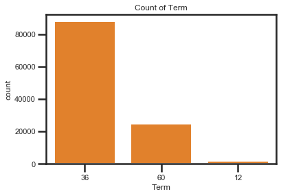

```python
#loan_CL.Term.hist(figsize=(8, 8));
#loan_CL['Term'].value_counts().plot(kind='bar', title='Count of Term');

term_order = loan_CL['Term'].value_counts().index

sb.countplot(data = loan_CL, x = 'Term', color = base_color, order = term_order)
plt.title('Count of Term')
plt.xticks(rotation = 0);
```

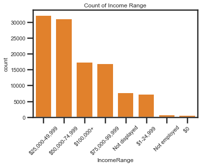

```python
income_order = loan_CL['IncomeRange'].value_counts().index

sb.countplot(data = loan_CL, x = 'IncomeRange', color = base_color, order = income_order)
plt.title('Count of Income Range')
plt.xticks(rotation = 45);
```

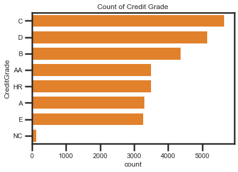

```python
credit_grade = loan_CL['CreditGrade'].value_counts().index

sb.countplot(data = loan_CL, y = 'CreditGrade', color = base_color, order = credit_grade)
plt.title('Count of Credit Grade');
```

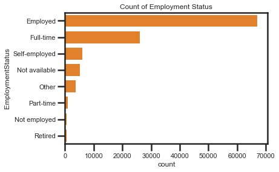

```python
emp_status = loan_CL['EmploymentStatus'].value_counts().index

sb.countplot(data = loan_CL, y = 'EmploymentStatus', color = base_color, order = emp_status)
plt.title('Count of Employment Status');
```

Above I just wanted to determine what where the large to small counts of various categories. Income Range, Credit Grade and Employment Status are major factors in seeking loans. Below I wanted to get various counts of certain categories and averages to find more points of interest.

```python
loan_CL['Occupation'].value_counts()
```

```
Other                          28617
Professional                   13628
Computer Programmer             4478
Executive                       4311
Teacher                         3759
                               ...
Dentist                           68
Student - College Freshman        41
Student - Community College       28
Judge                             22
Student - Technical School        16
Name: Occupation, Length: 67, dtype: int64
```

Here I'm looking at specific variables of interest. Exploring the mean and max values.

```python
loan_CL['BorrowerRate'].mean()
loan_CL['BorrowerRate'].max()
```

```
0.4975
```

```python
loan_CL['LenderYield'].mean()
loan_CL['LenderYield'].max()
```

```
0.4925
```

```python
loan_CL['CurrentDelinquencies'].mean()
```

```
0.5920522783468739
```

```python
loan_CL['CurrentDelinquencies'].max()
```

```
83.0
```

```python
loan_CL.EmploymentStatus.value_counts()
```

```
Employed         67322
Full-time        26355
Self-employed     6134
Not available     5347
Other             3806
Part-time         1088
Not employed       835
Retired            795
Name: EmploymentStatus, dtype: int64
```

```python
loan_CL.std()
```

```
Term                              10.436212
BorrowerAPR                        0.080364
BorrowerRate                       0.074818
LenderYield                        0.074516
EstimatedEffectiveYield            0.068467
EstimatedLoss                      0.046764
EstimatedReturn                    0.030403
ProsperRating_numeric              1.673227
ProsperScore                       2.376501
EmploymentStatusDuration          94.480605
IsBorrowerHomeowner                0.499982
CreditScoreRangeLower             66.458275
CreditScoreRangeUpper             66.458275
OpenRevolvingAccounts              4.630970
OpenRevolvingMonthlyPayment      447.159711
CurrentDelinquencies               1.978707
AmountDelinquent                7158.270157
RevolvingCreditBalance         32936.401788
DebtToIncomeRatio                  0.551759
StatedMonthlyIncome             7478.497276
LoanOriginalAmount              6245.800580
MonthlyLoanPayment               192.697812
Investors                        103.239020
dtype: float64
```

```python
loan_CL.LoanStatus.value_counts()
```

```
Current                   56576
Completed                 38074
Chargedoff                11992
Defaulted                  5018
Past Due (1-15 days)        806
Past Due (31-60 days)       363
Past Due (61-90 days)       313
Past Due (91-120 days)      304
Past Due (16-30 days)       265
FinalPaymentInProgress      205
Past Due (>120 days)         16
Cancelled                     5
Name: LoanStatus, dtype: int64
```

```python
loan_CL['BorrowerRate'].mean()
```

```
0.1927640577687518
```

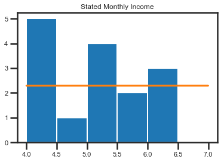

```python
bin_size = 0.5
bin_edges = np.arange(4, 7 + bin_size, bin_size)
plt.hist(data = loan_CL, x = 'StatedMonthlyIncome', bins = bin_edges);

samp_mean = loan_CL['StatedMonthlyIncome'].mean()
samp_sd = loan_CL['StatedMonthlyIncome'].std()

from scipy.stats import norm
x = np.linspace(4, 7, 200)
y = norm.pdf(x, samp_mean, samp_sd)
y *= loan_data.shape[0] * bin_size

plt.plot(x, y)
plt.title('Stated Monthly Income');
```

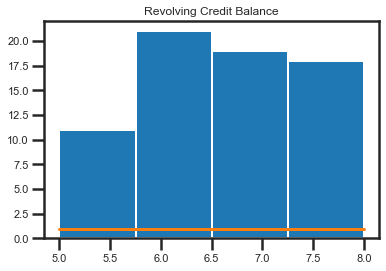

```python
bin_size = 0.75
bin_edges = np.arange(5, 8 + bin_size, bin_size)
plt.hist(data = loan_CL, x = 'RevolvingCreditBalance', bins = bin_edges);

samp_mean = loan_CL['RevolvingCreditBalance'].mean()
samp_sd = loan_CL['RevolvingCreditBalance'].std()

from scipy.stats import norm
x = np.linspace(5, 8, 200)
y = norm.pdf(x, samp_mean, samp_sd)
y *= loan_data.shape[0] * bin_size

plt.plot(x, y)
plt.title('Revolving Credit Balance');
```

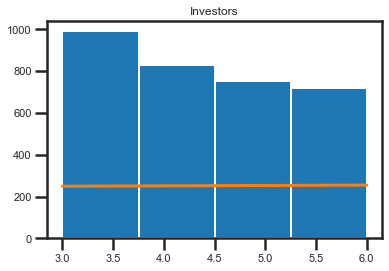

```python
bin_size = 0.75
bin_edges = np.arange(3, 6 + bin_size, bin_size)
plt.hist(data = loan_CL, x = 'Investors', bins = bin_edges);

samp_mean = loan_CL['Investors'].mean()
samp_sd = loan_CL['Investors'].std()

from scipy.stats import norm
x = np.linspace(3, 6, 20)
y = norm.pdf(x, samp_mean, samp_sd)
y *= loan_data.shape[0] * bin_size

plt.plot(x, y)
plt.title('Investors');
```

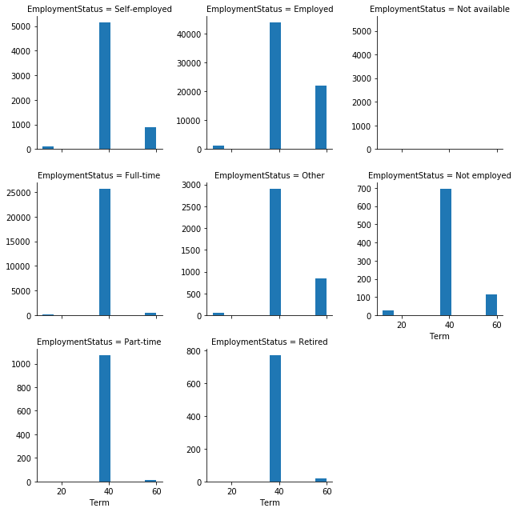

```python
#bins = np.arange(6, 29+2, 1)
g = sb.FacetGrid(data = loan_CL, col = 'EmploymentStatus', col_wrap = 3, sharey = False);
g.map(plt.hist, 'Term');
```

Now I’m looking at top five loan seekers. I also want to see the bottom five. This will give me an idea of what professions are seeking loans and could be a point of interest to a banking organization.

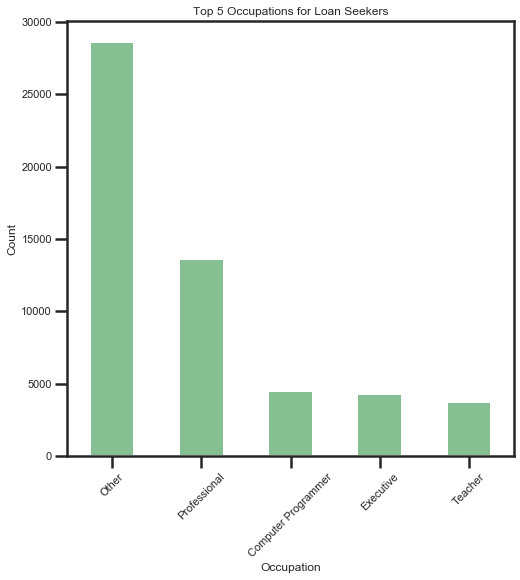

```python
top_five_jobs = loan_CL.Occupation.value_counts().head(5)
top_five_jobs.plot(kind='bar', figsize=(8, 8), color='#86bf91', zorder=2, width=0.5, title='Top 5 Occupations for Loan Seekers')
plt.xticks(rotation = 45)
plt.xlabel('Occupation')
plt.ylabel('Count');
```

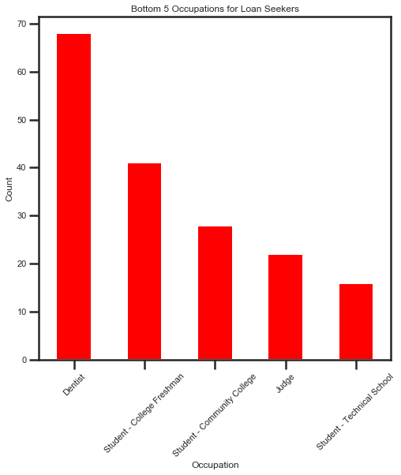

```python
last_five_jobs = loan_CL.Occupation.value_counts().tail(5)
last_five_jobs.plot(kind='bar', figsize=(8, 8), color='red', zorder=2, width=0.5, title='Bottom 5 Occupations for Loan Seekers')
plt.xticks(rotation = 45)
plt.xlabel('Occupation')
plt.ylabel('Count');
```

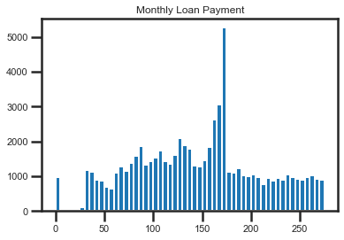

```python
bins = np.arange(0, loan_CL['MonthlyLoanPayment'].mean()+5, 5)
plt.hist(data = loan_CL, x = 'MonthlyLoanPayment', bins = bins)
plt.title('Monthly Loan Payment');
```

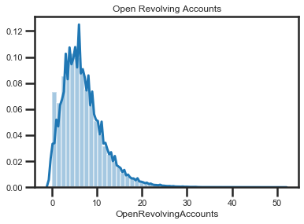

```python
sb.distplot(loan_CL['OpenRevolvingAccounts'])
plt.title('Open Revolving Accounts');
```

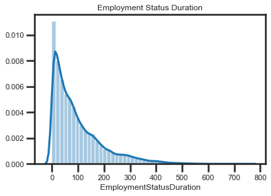

```python
sb.distplot(loan_CL['EmploymentStatusDuration'])
plt.title('Employment Status Duration');
```

### Discuss the distribution(s) of your variable(s) of interest. Were there any unusual points? Did you need to perform any transformations?

Occupation is a healthy list of 67 titles. Unfortunately, there is a variable for “Other”, which is understandable, but it is also the largest variable in the set. So, that is vague and may create outliers which cannot be identified. I do not need to create any transformations at this time.

### Of the features you investigated, were there any unusual distributions? Did you perform any operations on the data to tidy, adjust, or change the form of the data? If so, why did you do this?

One unusual distribution was in Term of loan. I had theorized that more loans would be towards the higher Term of 60, when in fact the maximum count is towards 36. Initially, Term was an integer and I changed it to a category. This is more appropriate in this case since we do not want to perform aggregation to the Term variable. It is a Qualitative variable that I would classify as Ordinal data.

## Bivariate Exploration

Back to Top

```python
Occs = loan_CL.groupby('Occupation')['LoanOriginalAmount'].mean()
Occs
```

```
Occupation
Accountant/CPA               9195.888339
Administrative Assistant     6598.893980
Analyst                      9160.769572
Architect                    9758.887324
Attorney                    11304.958891
                                ...
Tradesman - Electrician      9600.482180
Tradesman - Mechanic         8648.668770
Tradesman - Plumber          7746.460784
Truck Driver                 8180.587463
Waiter/Waitress              5350.050459
Name: LoanOriginalAmount, Length: 67, dtype: float64
```

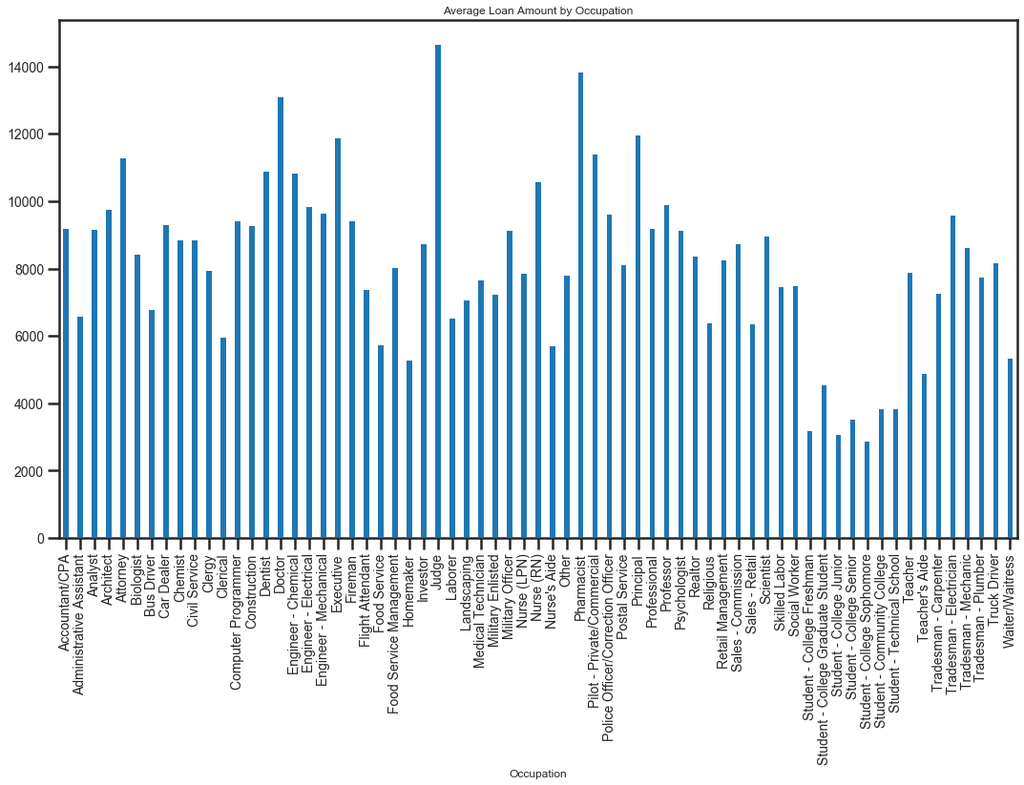

```python
Occs.plot(kind='bar', fontsize= 14, figsize = (18, 10))
plt.title('Average Loan Amount by Occupation');
```

Above we have a list of the average loan amount by Occupation and below is a list by Employment Status.

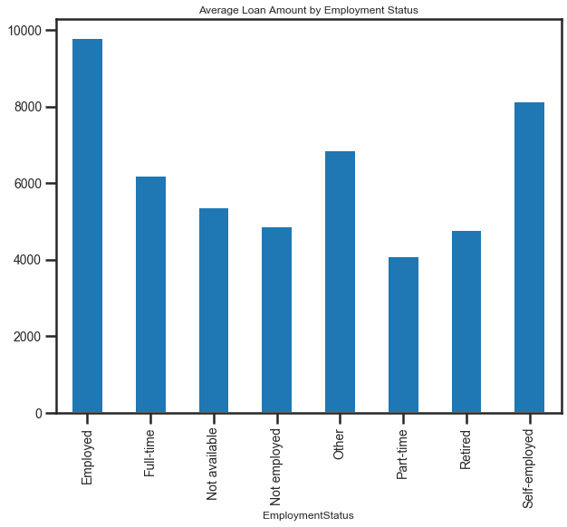

```python
emp_stats = loan_CL.groupby('EmploymentStatus')['LoanOriginalAmount'].mean()
emp_stats.plot(kind='bar', title='Average Loan Amount by Employment Status', fontsize= 14, figsize = (10, 8));
```

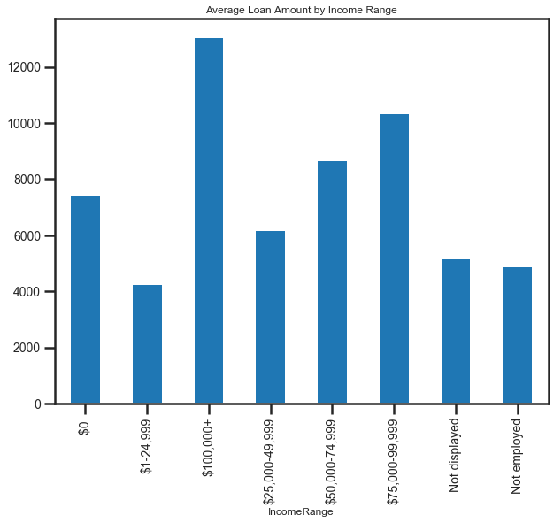

```python
income_stats = loan_CL.groupby('IncomeRange')['LoanOriginalAmount'].mean()
income_stats.plot(kind='bar', title='Average Loan Amount by Income Range', fontsize= 14, figsize = (10, 8));
```

```python
emp_counts = loan_CL.groupby(['EmploymentStatus', 'Term']).size()
emp_counts = emp_counts.reset_index(name = 'count')
emp_counts = emp_counts.pivot(index = 'EmploymentStatus', columns = 'Term', values = 'count')
```

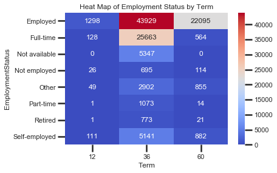

```python
sb.heatmap(emp_counts, annot = True, fmt = 'd', cmap = 'coolwarm')
plt.title('Heat Map of Employment Status by Term');
```

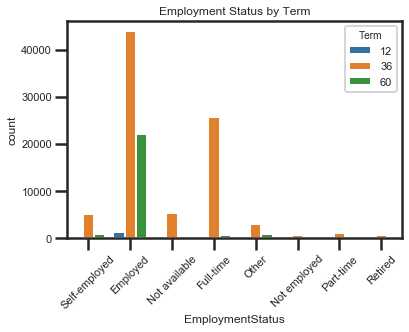

```python
sb.countplot(data = loan_CL, x ='EmploymentStatus', hue = 'Term')
plt.title('Employment Status by Term')
plt.xticks(rotation = 45);
```

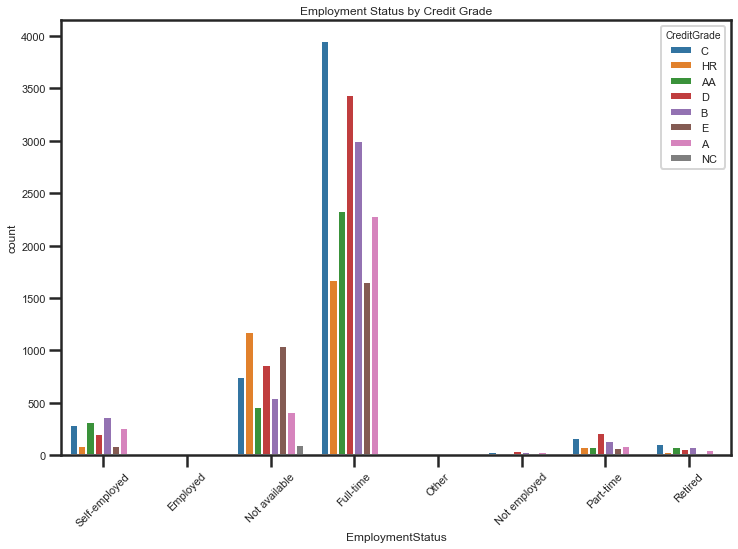

```python
plt.figure(figsize=(12,8))
sb.countplot(data = loan_CL, x ='EmploymentStatus', hue = 'CreditGrade')
plt.title('Employment Status by Credit Grade')
plt.xticks(rotation = 45);
```

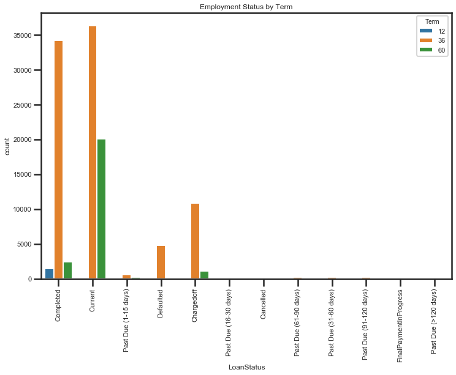

```python
plt.figure(figsize=(12,8))
sb.countplot(data = loan_CL, x ='LoanStatus', hue = 'Term')
plt.title('Employment Status by Term')
plt.xticks(rotation = 90);
```

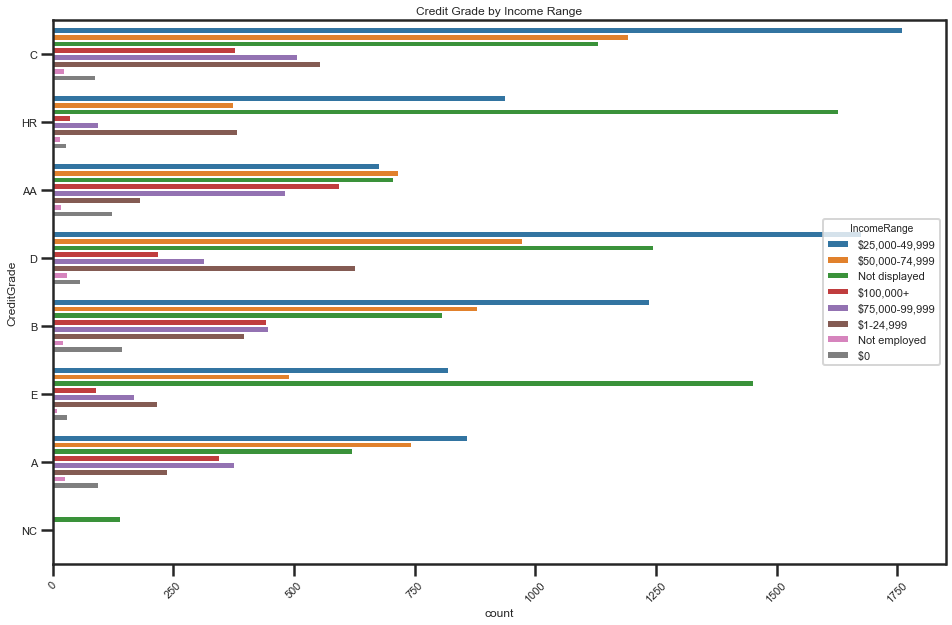

```python
plt.figure(figsize=(16,10))
sb.countplot(data = loan_CL, y ='CreditGrade', hue = 'IncomeRange')
plt.title('Credit Grade by Income Range')
plt.xticks(rotation = 45);
```

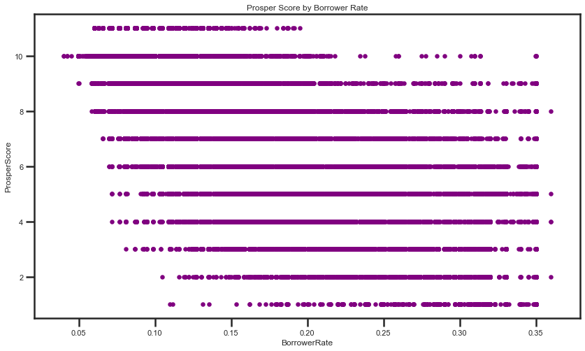

```python
loan_CL.plot(kind='scatter', x='BorrowerRate', y='ProsperScore', title='Prosper Score by Borrower Rate', color='purple', figsize=(14, 8));
```

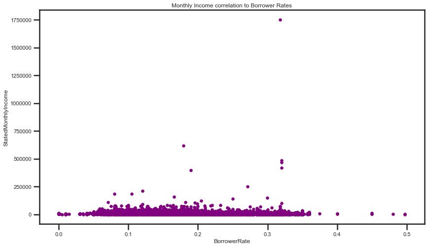

```python
#loan_data.plot(kind='scatter', x='DebtToIncomeRatio', y='StatedMonthlyIncome', color='purple', title='Monthly Income correlation to Debt Ratio', figsize=(14, 8));
loan_CL.plot(kind='scatter', x='BorrowerRate', y='StatedMonthlyIncome', color='purple', title='Monthly Income correlation to Borrower Rates', figsize=(14, 8));
```

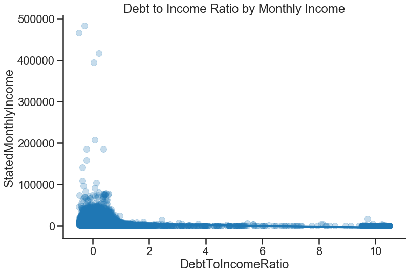

```python
sb.set_style('ticks')
sb.set_context("poster", font_scale = 1)
fig, ax = plt.subplots()
ax.set_title('Debt to Income Ratio by Monthly Income')
fig.set_size_inches(12, 8)
sb.regplot(data = loan_CL, x='DebtToIncomeRatio', y='StatedMonthlyIncome', x_jitter = 0.5,
              scatter_kws = {'alpha' : 1/4} )
sb.despine();
```

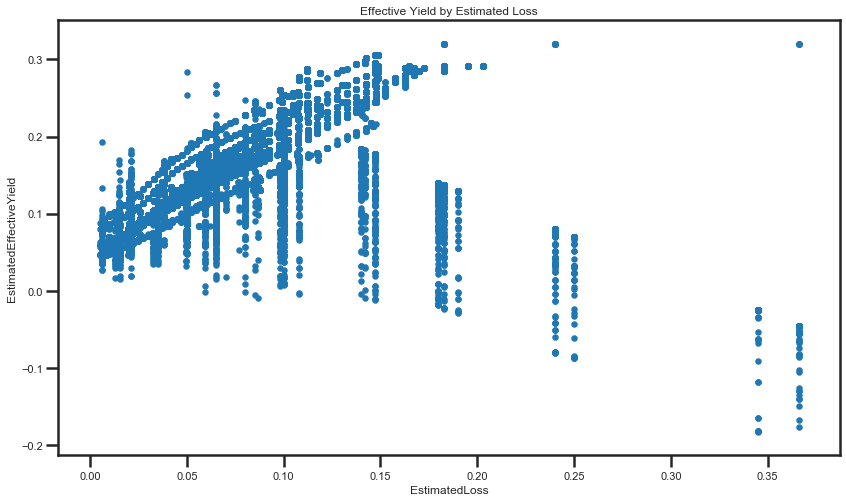

```python
loan_CL.plot(kind='scatter', x='EstimatedLoss', y='EstimatedEffectiveYield', figsize=(14, 8))
plt.title('Effective Yield by Estimated Loss');
```

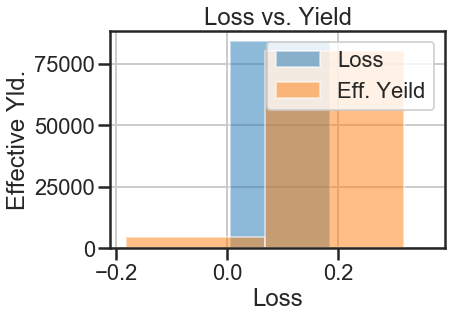

```python
loan_CL['EstimatedLoss'].hist(alpha=0.5, bins=2, label='Loss')
loan_CL['EstimatedEffectiveYield'].hist(alpha=0.5, bins=2, label='Eff. Yeild')
plt.xlabel('Loss')
plt.ylabel('Effective Yld.')
plt.title('Loss vs. Yield')
plt.legend();
```

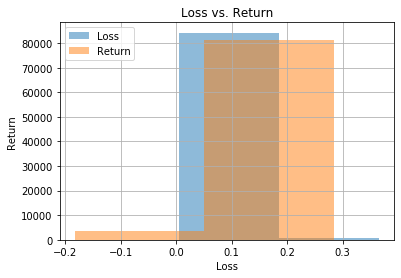

```python
loan_CL['EstimatedLoss'].hist(alpha=0.5, bins=2, label='Loss')
loan_CL['EstimatedReturn'].hist(alpha=0.5, bins=2, label='Return')
plt.xlabel('Loss')
plt.ylabel('Return')
plt.title('Loss vs. Return')
plt.legend();
```

### Talk about some of the relationships you observed in this part of the investigation. How did the feature(s) of interest vary with other features in the dataset?

First of all, “Term” was interesting. I would have imagined most loan seekers would go for the higher term of 60 months but, 36 seems to hold the majority across various employment status. Then, I charted EmploymentSatus with CreditGrade, which produced some unusual results in the Employed attribute. It seems those seeking loans that were Employed did not record markings for CreditGrade? That seemed curious. I further investigated the relationship between CreditGrade and IncomeRange.

### Did you observe any interesting relationships between the other features (not the main feature(s) of interest)?

BorrowerRate correlation ot StatedMonthlyIncome showed a few outliers. One where a higher BorrowerRate and a large Monthly income was very clear and noticeable in a Scatter Plot. That prompted me to look at StatedMonthlyIncome to DebtToIncomeRatio. As expected, the higher the monthly income the lower the debt ratio. Although it was a sharp drop in scale. Indicating that a large number of applicants with low monthly income have a high debt ratio.

## Multivariate Exploration

Here I want to explore BorrowerRate, APR, and LenderYield along with other factors that effect a loan applications. In my conclusion I want to explore categories by IncomeRange. IncomeRange is set as a category and gives me a nice measuring point to explore statistics of my data set.

Back to Top

```python
loan_CL.head(3)
```

|  | ListingNumber | ListingCreationDate | CreditGrade | Term | LoanStatus | BorrowerAPR | BorrowerRate | LenderYield | EstimatedEffectiveYield | EstimatedLoss | ... | AmountDelinquent | RevolvingCreditBalance | DebtToIncomeRatio | IncomeRange | StatedMonthlyIncome | LoanOriginalAmount | LoanOriginationDate | LoanOriginationQuarter | MonthlyLoanPayment | Investors |
| --- | --- | --- | --- | --- | --- | --- | --- | --- | --- | --- | --- | --- | --- | --- | --- | --- | --- | --- | --- | --- | --- |
| 0 | 193129 | 09:29.3 | C | 36 | Completed | 0.16516 | 0.158 | 0.138 | NaN | NaN | ... | 472.0 | 0.0 | 0.17 | $25,000-49,999 | 3083.333333 | 9425 | 2007-09-12 | Q3 2007 | 330.43 | 258 |
| 1 | 1209647 | 28:07.9 | NaN | 36 | Current | 0.12016 | 0.092 | 0.082 | 0.0796 | 0.0249 | ... | 0.0 | 3989.0 | 0.18 | $50,000-74,999 | 6125.000000 | 10000 | 2014-03-03 | Q1 2014 | 318.93 | 1 |
| 2 | 81716 | 00:47.1 | HR | 36 | Completed | 0.28269 | 0.275 | 0.240 | NaN | NaN | ... | NaN | NaN | 0.06 | Not displayed | 2083.333333 | 3001 | 2007-01-17 | Q1 2007 | 123.32 | 41 |

3 rows × 34 columns

```python
np.random.seed(2018)
sample = np.random.choice(loan_CL.shape[0], 200, replace = False)
loan_CL_subset = loan_CL.loc[sample]
```

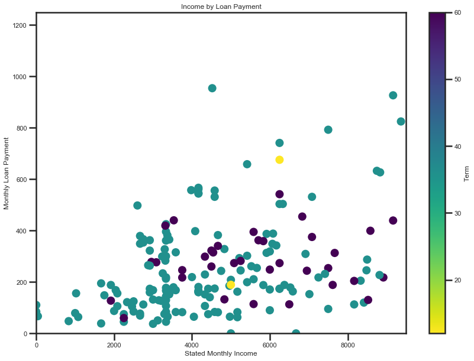

```python
plt.figure(figsize = [14,10])
plt.scatter(data = loan_CL_subset, x = 'StatedMonthlyIncome', y = 'MonthlyLoanPayment', c = 'Term', cmap = 'viridis_r')

plt.colorbar(label = 'Term')
plt.xlim(0,9500)
plt.ylim(0,1250)
plt.title('Income by Loan Payment')
plt.xlabel('Stated Monthly Income')
plt.ylabel('Monthly Loan Payment');
```

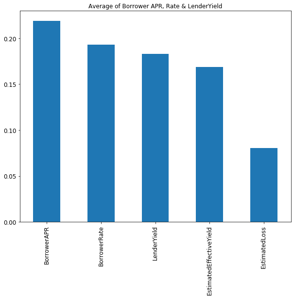

```python
loan_stats = loan_CL.agg({'BorrowerAPR' : 'mean',
                          'BorrowerRate' : 'mean',
                          'LenderYield' : 'mean',
                         'EstimatedEffectiveYield' : 'mean',
                         'EstimatedLoss' : 'mean'})

loan_stats.plot(kind='bar', title= 'Average of Borrower APR, Rate & LenderYield', fontsize = 12, figsize = (10, 8));
```

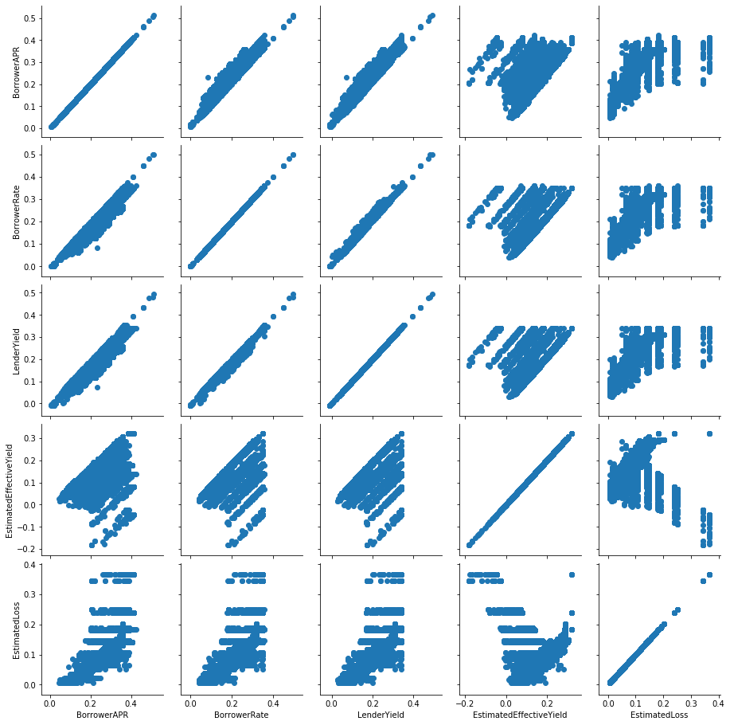

```python
loan_stats = ['BorrowerAPR', 'BorrowerRate', 'LenderYield', 'EstimatedEffectiveYield', 'EstimatedLoss']
g = sb.PairGrid(data = loan_CL, vars = loan_stats);
g.map(plt.scatter);
```

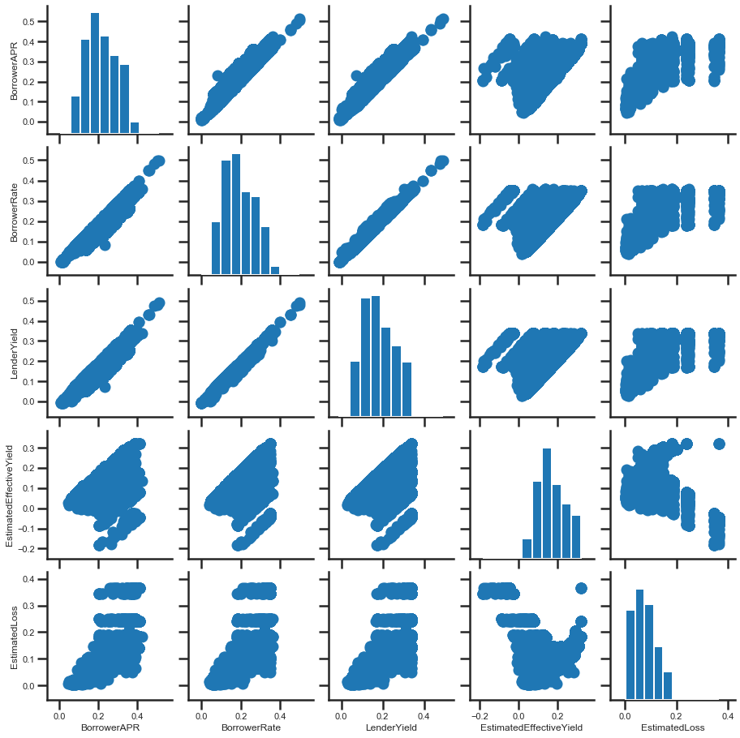

```python
loan_stats = ['BorrowerAPR', 'BorrowerRate', 'LenderYield', 'EstimatedEffectiveYield', 'EstimatedLoss']
sb.set_context("poster", font_scale = .5)
g = sb.PairGrid(data = loan_CL, vars = loan_stats);
g = g.map_offdiag(plt.scatter);
g.map_diag(plt.hist);
```

```python
loan_CL[loan_stats].corr()
```

|  | BorrowerAPR | BorrowerRate | LenderYield | EstimatedEffectiveYield | EstimatedLoss |
| --- | --- | --- | --- | --- | --- |
| BorrowerAPR | 1.000000 | 0.989824 | 0.989329 | 0.895635 | 0.949538 |
| BorrowerRate | 0.989824 | 1.000000 | 0.999211 | 0.895282 | 0.945297 |
| LenderYield | 0.989329 | 0.999211 | 1.000000 | 0.895343 | 0.945308 |
| EstimatedEffectiveYield | 0.895635 | 0.895282 | 0.895343 | 1.000000 | 0.798135 |
| EstimatedLoss | 0.949538 | 0.945297 | 0.945308 | 0.798135 | 1.000000 |

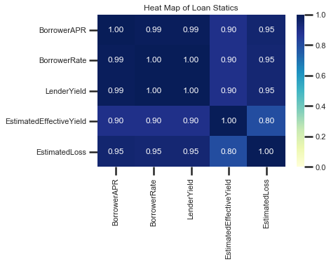

```python
sb.heatmap(loan_CL[loan_stats].corr(), cmap="YlGnBu", annot = True, fmt = '.2f', vmin = 0)
plt.title('Heat Map of Loan Statics');
```

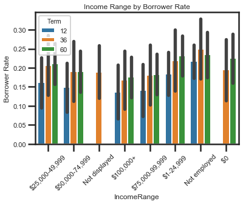

```python
sb.barplot(data = loan_CL, x = 'IncomeRange', y = 'BorrowerRate', hue = 'Term',
             ci = 'sd');
plt.xticks(rotation = 45)
plt.title('Income Range by Borrower Rate')
plt.ylabel('Borrower Rate');
```

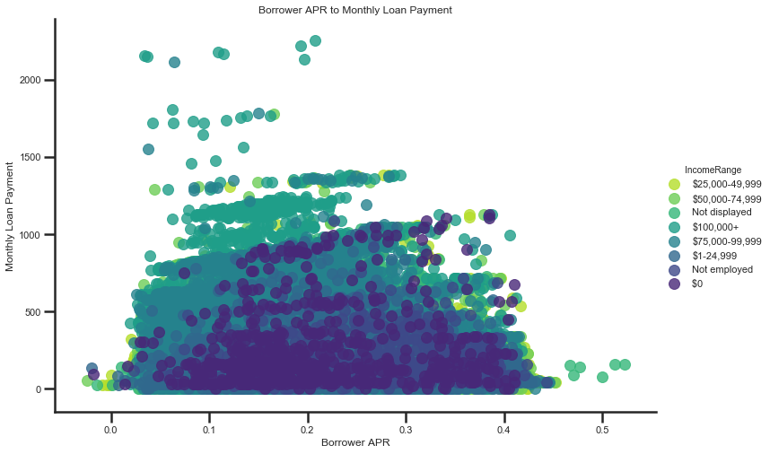

```python
g = sb.FacetGrid(data = loan_CL, hue = 'IncomeRange',
                height = 7, aspect = 1.5, palette = 'viridis_r')
g = g.map(sb.regplot, 'BorrowerAPR', 'MonthlyLoanPayment', x_jitter = 0.04, fit_reg = False);
g.add_legend()
plt.xlabel('Borrower APR')
plt.title('Borrower APR to Monthly Loan Payment')
plt.ylabel('Monthly Loan Payment');
```

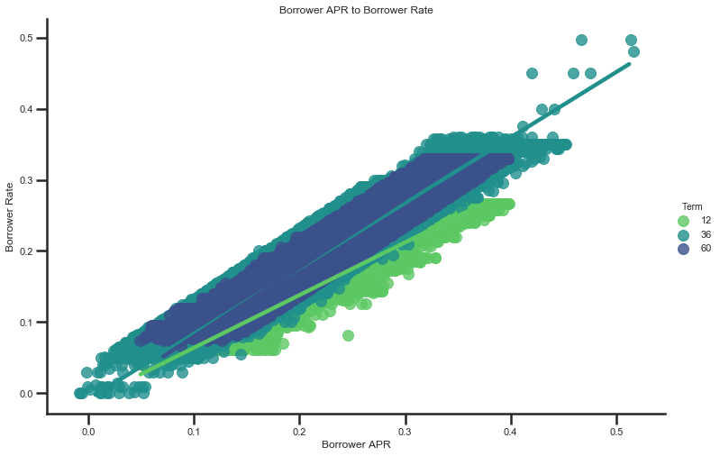

```python
g = sb.FacetGrid(data = loan_CL, hue = 'Term',
                height = 7, aspect = 1.5, palette = 'viridis_r')
g = g.map(sb.regplot, 'BorrowerAPR', 'BorrowerRate', x_jitter = 0.04);
g.add_legend()
plt.xlabel('Borrower APR')
plt.title('Borrower APR to Borrower Rate')
plt.ylabel('Borrower Rate');
```

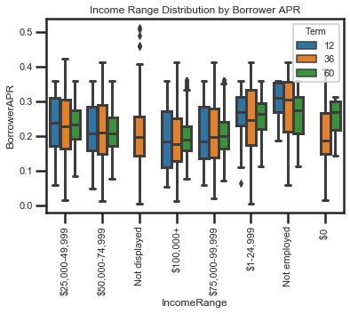

```python
sb.boxplot(data = loan_CL, x = 'IncomeRange', y = 'BorrowerAPR', hue = 'Term');
plt.title('Income Range Distribution by Borrower APR')
plt.xticks(rotation = 90);
```

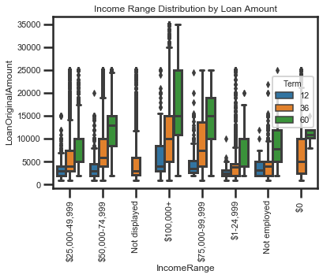

```python
sb.boxplot(data = loan_CL, x = 'IncomeRange', y = 'LoanOriginalAmount', hue = 'Term');
plt.title('Income Range Distribution by Loan Amount')
plt.xticks(rotation = 90);
```

### Talk about some of the relationships you observed in this part of the investigation. Were there features that strengthened each other in terms of looking at your feature(s) of interest?

So, in this section I started by exploring the mean of certain key factors for loan applicants. The average of BorrowerAPR, BorrowerRate, LenderYield, EstimatedEffectiveYield and EstimatedLoss were explored in scatter and histogram plots. Lender Yield had positive correlation with Borrower APR and Rates.

## Conclusion

Back to Top

To conclude, the data set featured loan applicant data. I explored several variables and compared the more interesting variables by Income Range of the applicants. I performed some bivariate exploration to discover trends in Employment Status by Term of loans. As well as, in category of Credit Grade. Then, I explored Credit Grade by Income Range. My inquiries revealed trends for the 25k to 49.9k to be the larger group on loan applicants in this data set. I ended my analysis with box plots on Income Range and Borrower APR and Loan Amount.

Originally, I sought to identify the average loan amount by occupation. As I dive deeper in my analysis, I sought to narrow the categories down to by employment status and income range.

Listing by income range would be a more general category and it is a major factor for loan applicants. This could be used as a baseline for what loan amount an applicant may qualify for.